# Supervised Multiblock analyses

Florence Mehl

November 27, 2024

# Nutrimouse dataset

The data sets come from a nutrigenomic study in the mouse (Martin et al., 2007, https://aasldpubs.onlinelibrary.wiley.com/doi/pdfdirect/10.1002/hep.21510) in which the effects of five regimens with contrasted fatty acid compositions on liver lipids and hepatic gene expression in mice were considered.

Two sets of variables were acquired on forty mice: - genes: expressions of 120 genes measured in liver cells, selected (among about 30,000) as potentially relevant in the context of the nutrition study. These expressions come from a nylon macroarray with radioactive labelling - lipids: concentrations (in percentages) of 21 hepatic fatty acids measured by gas chromatography

Biological units (mice) were cross-classified according to two factors experimental design (4 replicates): - genotype: 2-levels factor, wild-type (WT) and PPARalpha -/- (PPAR) - diet: 5-levels factor. Oils used for experimental diets preparation were corn and colza oils (50/50) for a reference diet (REF), hydrogenated coconut oil for a saturated fatty acid diet (COC), sunflower oil for an Omega6 fatty acid-rich diet (SUN), linseed oil for an Omega3-rich diet (LIN) and corn/colza/enriched fish oils for the FISH diet (43/43/14)

```r
data("nutrimouse")
genes <- nutrimouse$gene
lipids <- nutrimouse$lipid
metadata <- data.frame(genotype = nutrimouse$genotype, diet = nutrimouse$diet)
metadata$sample_name <- paste0(rownames(metadata), "_", metadata$genotype, "_", metadata$diet)
rownames(genes) <- metadata$sample_name
rownames(lipids) <- metadata$sample_name
```

# Consensus OPLS Discriminant analysis of genotypes

## Question 1: based on lipids and genes data, can we discriminate wt vs ppar samples ?

Run ConsensusOPLS-DA analysis with ConsensusOPLS() from ConsensusOPLS package

```r
COPLS_data <- list(genes=as.matrix(genes), lipids=as.matrix(lipids))
COPLS_data <- lapply(COPLS_data, scale)
genotype <- metadata$genotype
dummy_genotype <- as.matrix(data.frame(wt = ifelse(genotype == "wt", 1, 0),ppar = ifelse(genotype == "ppar", 1, 0)))

COPLS_res <- ConsensusOPLS(
  data = COPLS_data,
  Y = dummy_genotype,
  maxPcomp = 1,
  maxOcomp = 1,
  modelType = "da",
  cvType = "nfold",
  nfold = 40,
  nperm = 100,
  verbose = T)

COPLS_res
```

```
## ***Optimal Consensus OPLS model***
##
## Mode:  da
##
## Number of predictive components:  1
##
## Number of orthogonal components:  1
##
## Block contribution:
##              p_1       o_1
## genes  0.4393358 0.4482196
## lipids 0.5606642 0.5517804
##
## Explained variance R2 in response: 0.9506812
##
## Predictive ability (cross validation Q2):  0.9256023
```

## Question 2: Is the model statistically significant?

The results of permutations can be found in `COPLS_res$permStats`. The results for the optimal model can be found in `COPLS_res$optimal$modelCV` and `COPLS_res$optimal$modelCV$cv`

- plot Q2 permutations
- plot DQ2 permutations
- plot R2Y permutations

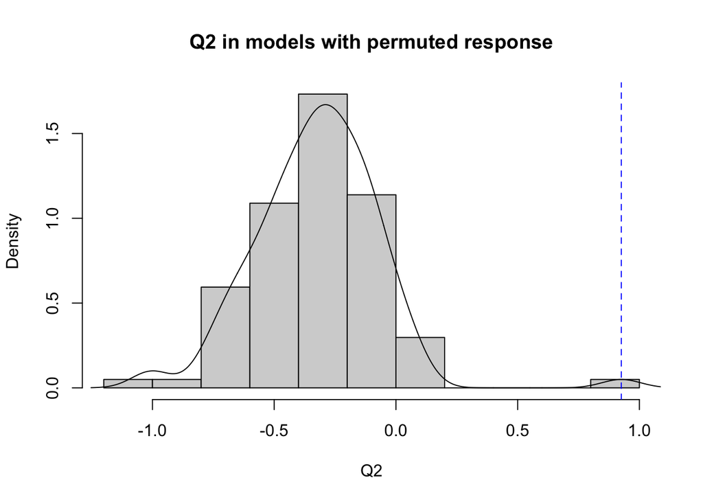

```r
# package's functions
#######################

# plot Q2 values from permutation tests histogram
plotQ2(COPLS_res)
```

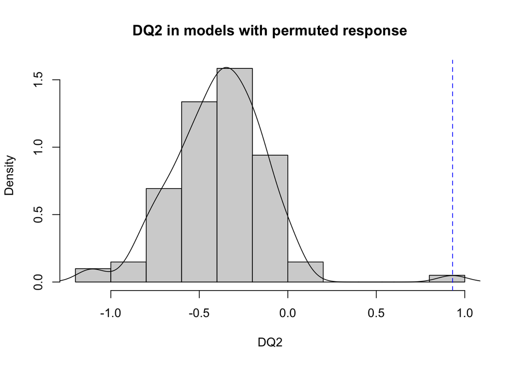

```r
# plot Q2 values from permutation tests histogram
plotDQ2(COPLS_res)
```

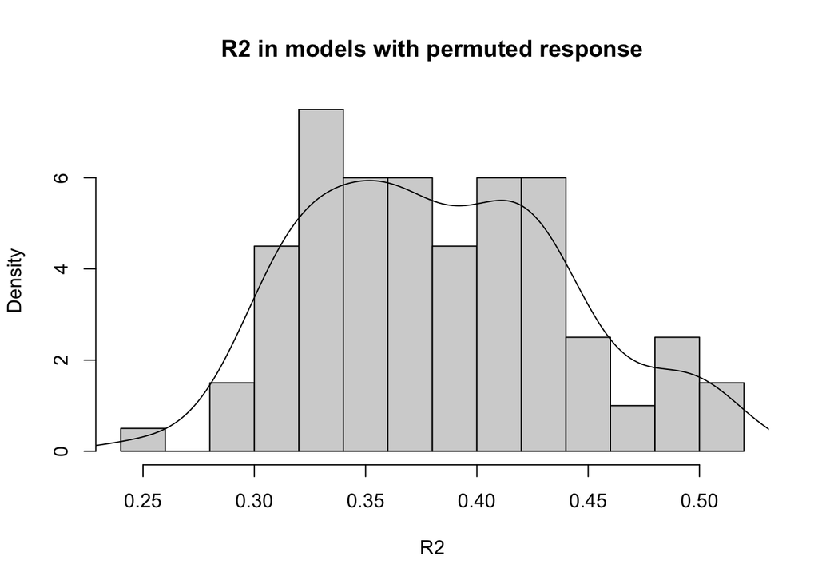

```r
# plot R2Y values from permutation tests histogram
plotR2(COPLS_res)
```

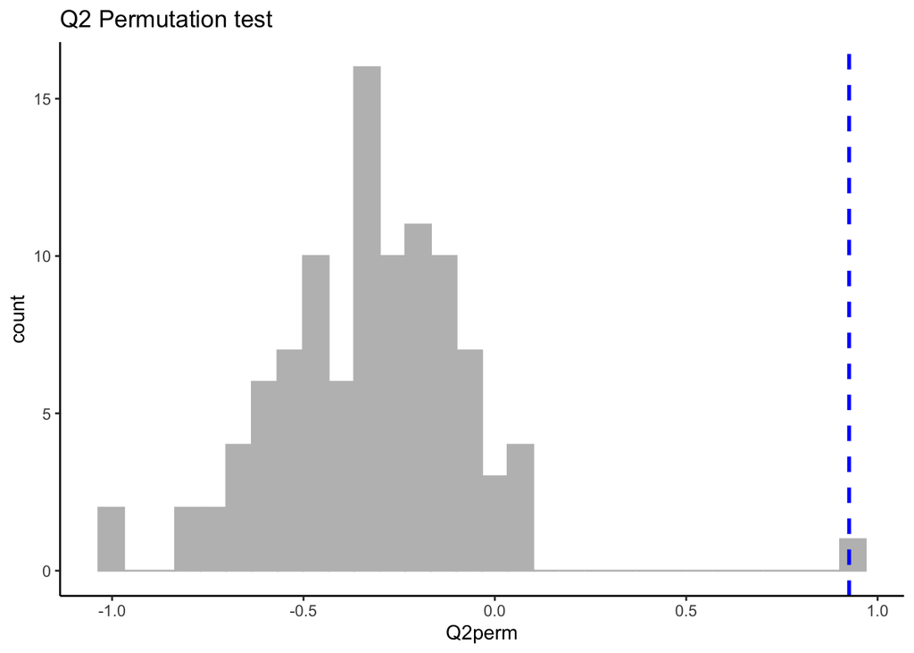

```r
# or draw your own plots
#######################

Q2perm <- data.frame(Q2perm = COPLS_res@permStats$Q2Y)

ggplot(data = Q2perm, aes(x = Q2perm)) +
  geom_histogram(color="grey", fill="grey") +
  geom_vline(aes(xintercept=COPLS_res@Q2["po1"]),color="blue", linetype="dashed", size=1) +
  theme_classic() +
  ggtitle("Q2 Permutation test")
```

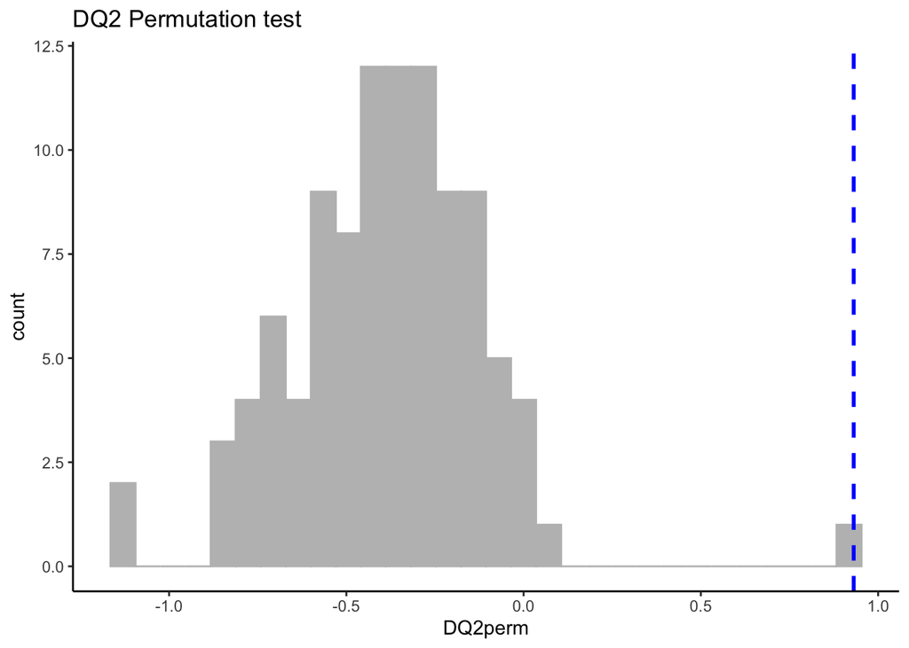

```r
DQ2perm <- data.frame(DQ2perm = COPLS_res@permStats$DQ2Y)

ggplot(data = DQ2perm, aes(x = DQ2perm)) +
  geom_histogram(color="grey", fill="grey") +
  geom_vline(aes(xintercept=COPLS_res@DQ2["po1"]),color="blue", linetype="dashed", size=1) +
  theme_classic() +
  ggtitle("DQ2 Permutation test")
```

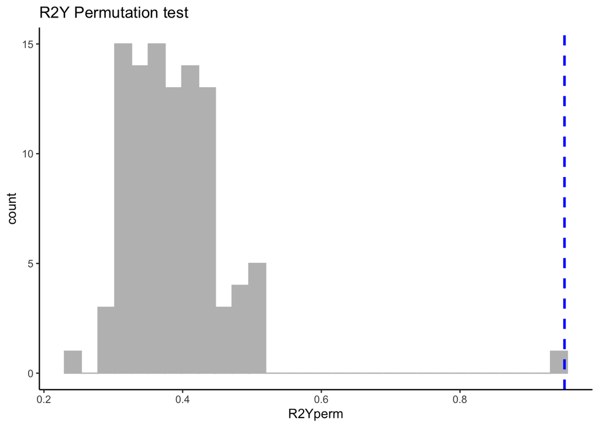

```r
R2Yperm <- data.frame(R2Yperm = COPLS_res@permStats$R2Y)

ggplot(data = R2Yperm, aes(x = R2Yperm)) +
  geom_histogram(color="grey", fill="grey") +
  geom_vline(aes(xintercept=COPLS_res@R2Y["po1"]),color="blue", linetype="dashed", size=1) +
  theme_classic() +
  ggtitle("R2Y Permutation test")
```

## Question 3: What is the contribution of each data block?

- plot blockContribution of the optimal model

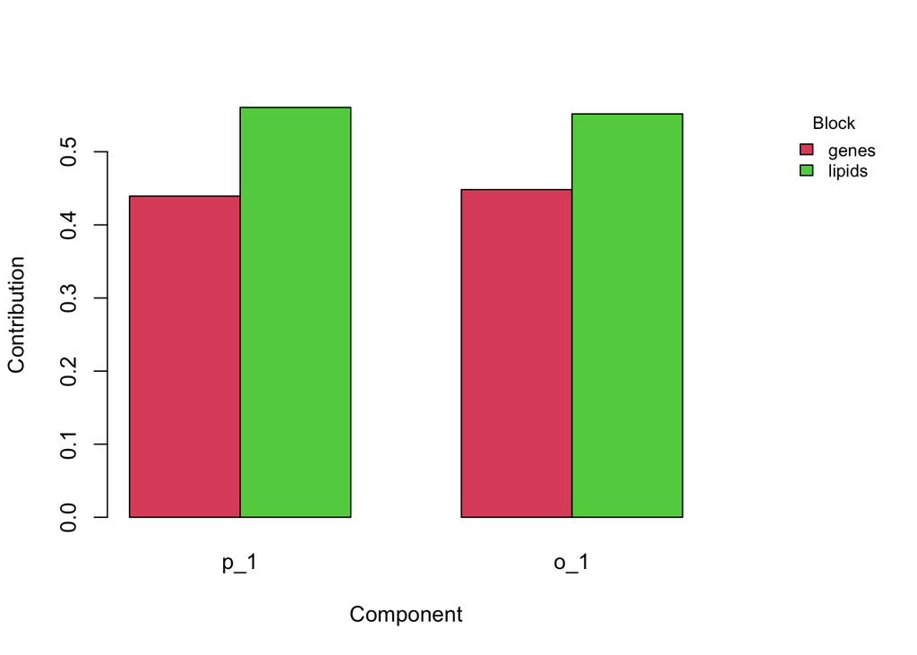

```r
# package's function
#######################

# plot Q2 values from permutation tests histogram
plotContribution(COPLS_res)
```

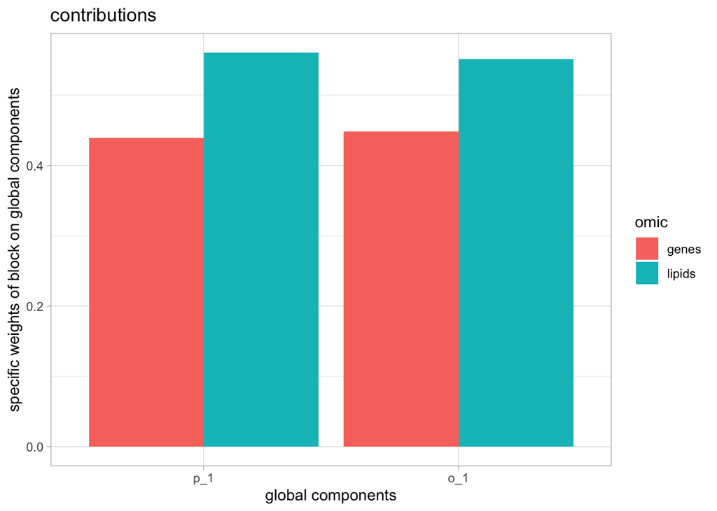

```r
# or draw your own plot
#######################

contributions <- COPLS_res@blockContribution
contributions <- melt(contributions)
colnames(contributions) <- c("dataset", "Dim", "value")

ggplot(contributions, aes(x=Dim, y=value, fill=dataset)) +
  geom_bar(stat = "identity", position=position_dodge()) +
  theme_light() +
  labs(x = "global components", y = "specific weights of block on global components", fill = "omic",
       title = "contributions")
```

## Question 4: Show the distribution of samples in the space of the predictive and orthogonal latent variables?

- plot scores of the optimal model

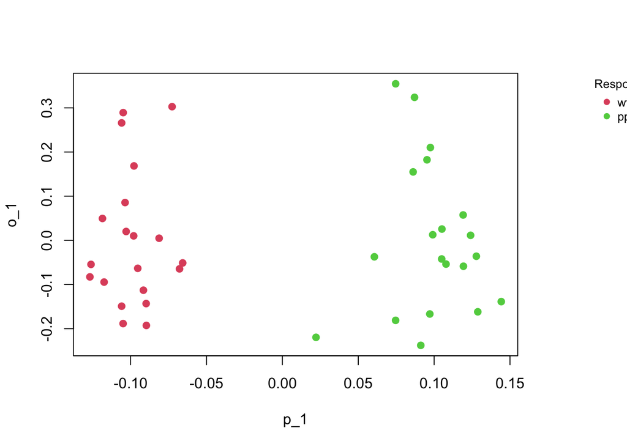

```r
# package's functions
#######################

# plot Q2 values from permutation tests histogram
plotScores(COPLS_res)
```

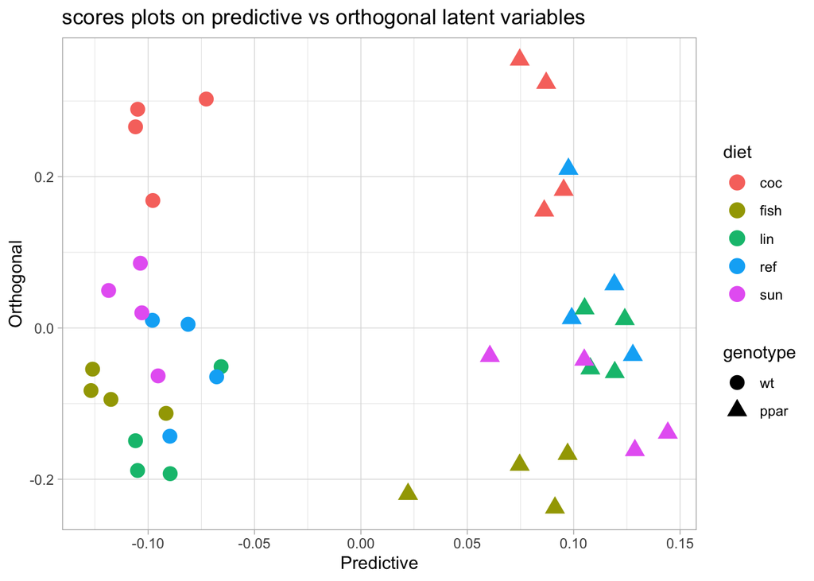

```r
# or draw your own plot
#######################

scores <- data.frame(metadata, COPLS_res@scores)

ggplot(scores, aes(x=p_1, y=o_1, col=diet, shape = genotype)) +
  geom_point(size=4) +
  labs(x="Predictive",
       y="Orthogonal",
       title = "scores plots on predictive vs orthogonal latent variables") +
  theme_light()
```

## Question 5: Show the loadings of variables in the space of the predictive and orthogonal latent variables?

- plot loadings of the optimal model

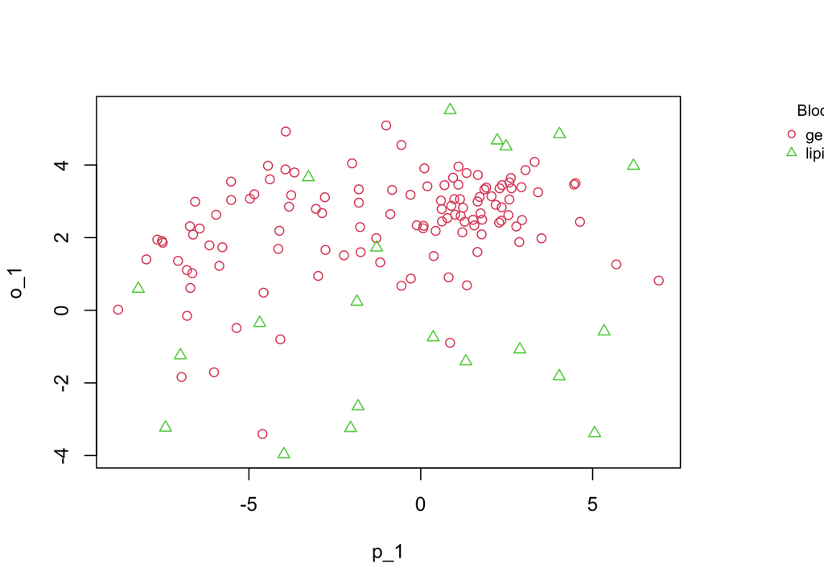

```r
# package's functions
#######################

# plot Q2 values from permutation tests histogram
plotLoadings(COPLS_res)
```

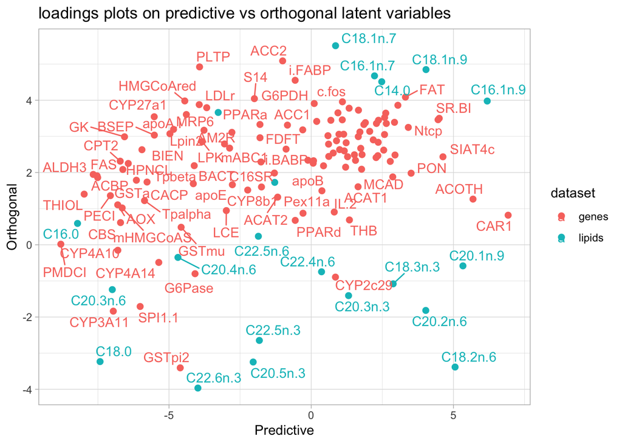

```r
# or draw your own plot
#######################

loadings <- rbind.data.frame(COPLS_res@loadings$genes, COPLS_res@loadings$lipids)
loadings$dataset <- c(rep("genes", nrow(COPLS_res@loadings$genes)), rep("lipids", nrow(COPLS_res@loadings$lipids)))
loadings$variable <- rownames(loadings)

ggplot(loadings, aes(x=p_1, y=o_1, col=dataset, label = variable)) +
  geom_point(size=2) +
  labs(x="Predictive",
       y="Orthogonal",
       title = "loadings plots on predictive vs orthogonal latent variables") +
  geom_text_repel() +
  theme_light()
```

## Question 6: Show the importance of variables in the model?

- plot loadings and VIP of the optimal model

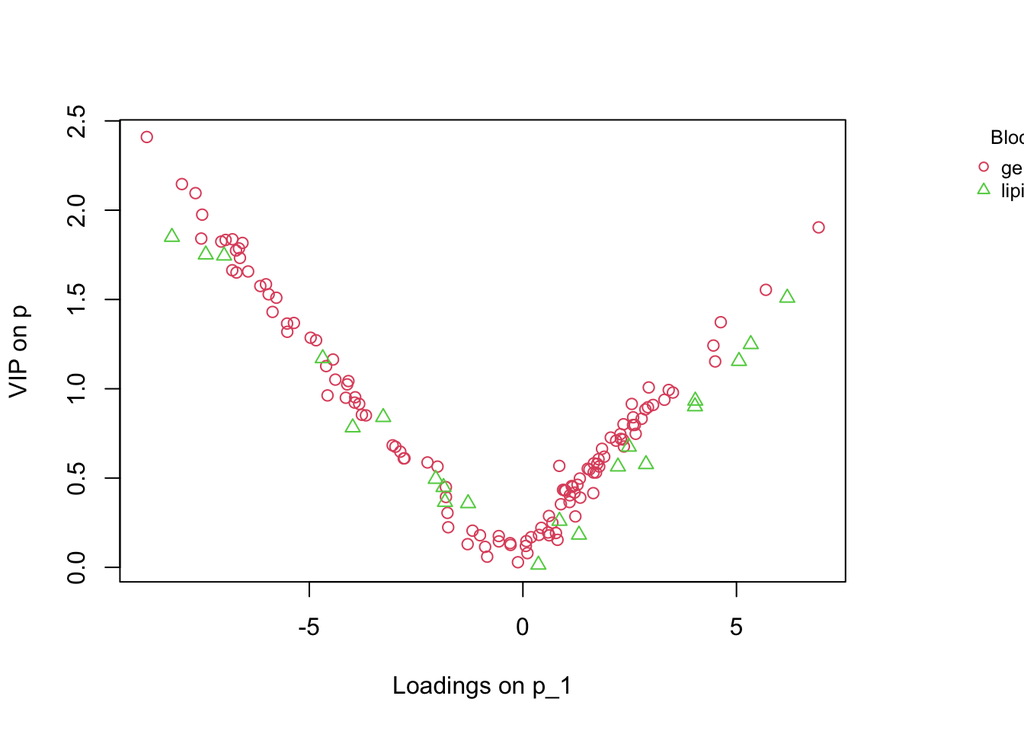

```r
# package's functions
#######################

# plot Q2 values from permutation tests histogram
plotVIP(COPLS_res)
```

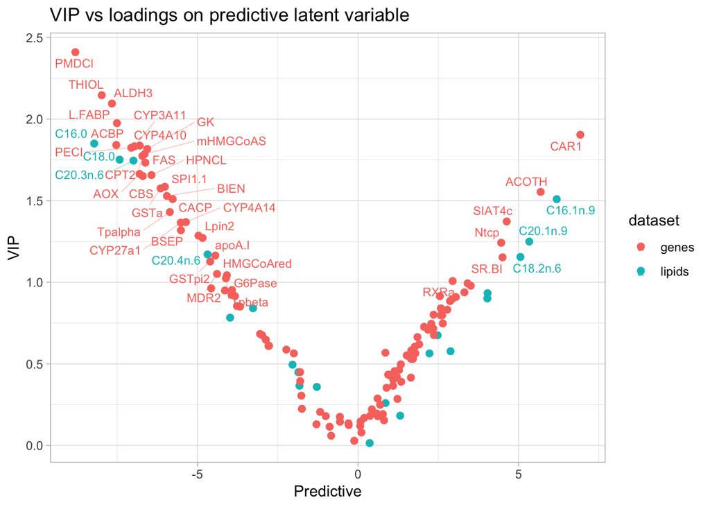

```r
# or draw your own plot
#######################

VIP <- data.frame(VIP = c(COPLS_res@VIP$genes[,"p"], COPLS_res@VIP$lipids[,"p"]), variable = c(rownames(COPLS_res@VIP$genes), rownames(COPLS_res@VIP$lipids)))

loadings_VIP <- merge(loadings, VIP, by="variable")
loadings_VIP$label <- ifelse(loadings_VIP$VIP > 1, loadings_VIP$variable, NA)

ggplot(loadings_VIP, aes(x=p_1, y=VIP, col=dataset, label = label)) +
  geom_point(size=2) +
  labs(x="Predictive",
       y="VIP",
       title = "VIP vs loadings on predictive latent variable") +
  geom_text_repel(size=3, max.overlaps = 50, segment.size=.1) +
  theme_light()
```